# R Notebook

In all plots you make, ensure your labels are appropriate. You also must write down a short summary of what each plot tells you in order to meet MVP.

Q1.

```r
library(CodeClanData)
library(ggplot2)
library(tidyverse)
```

```r
backpack
```

| backpack_weight | body_weight | ratio | back_problems | major | year | sex | status | units |
| --- | --- | --- | --- | --- | --- | --- | --- | --- |
| 9 | 125 | 0.0720000 | 1 | Bio | 3 | Female | U | 13 |
| 8 | 195 | 0.0410256 | 0 | Philosophy | 5 | Male | U | 12 |
| 10 | 120 | 0.0833333 | 1 | GRC | 4 | Female | U | 14 |
| 6 | 155 | 0.0387097 | 0 | CSC | 6 | Male | G | 0 |
| 8 | 180 | 0.0444444 | 0 | EE | 2 | Female | U | 14 |
| 5 | 240 | 0.0208333 | 0 | History | 0 | Male | G | 0 |
| 8 | 170 | 0.0470588 | 0 | CM | 3 | Male | U | 15 |
| 4 | 185 | 0.0216216 | 1 | ARCE | 5 | Female | U | 18 |
| 5 | 130 | 0.0384615 | 0 | Bio | 4 | Female | U | 14 |
| 2 | 120 | 0.0166667 | 0 | Bio | 5 | Female | U | 8 |

[output cut: 90 more lines]

```r
NA
```

```r
# This gives the dimesnsions and names of this dataset
dim(backpack)
```

```
[1] 100   9
```

```r
names(backpack)
```

```
[1] "backpack_weight" "body_weight"     "ratio"           "back_problems"   "major"
[6] "year"            "sex"             "status"          "units"
```

SOLUTION

```r
head(backpack)
names(backpack)
```

[output not shown]

Q2. What is the distribution of backpack weights that students are carrying? Choose an appropriate graph to show the distribution.

[figure not shown]

```r
ggplot(backpack) +
  geom_bar(aes(x = backpack_weight, fill = body_weight), position = "dodge") +
  scale_fill_brewer()
```

This graph shows that most students carried between 5 -10 (LBS) in backpack_weight

SOLUTION

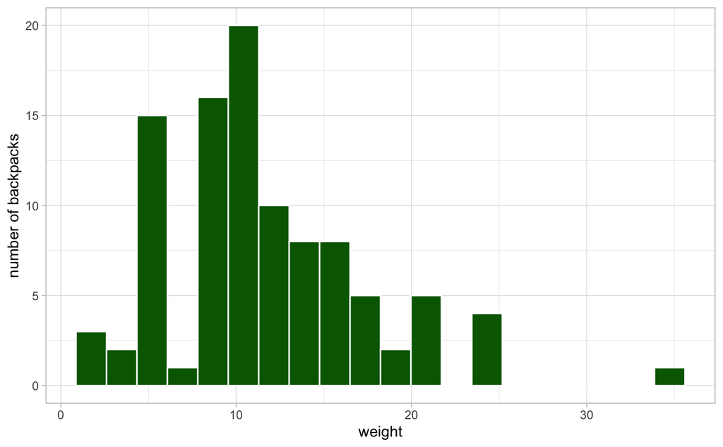

```r
# distribution of backpack weight
ggplot(backpack) +
  aes(x = backpack_weight) +
  geom_histogram(bins = 20, col = "white", fill = "dark green") +
  theme_light() +
  labs(y = "number of backpacks", x = "weight")
```

Most are howevering between 5-15 backpack weights.

Q3. Are there differences in backpack weight between sex?

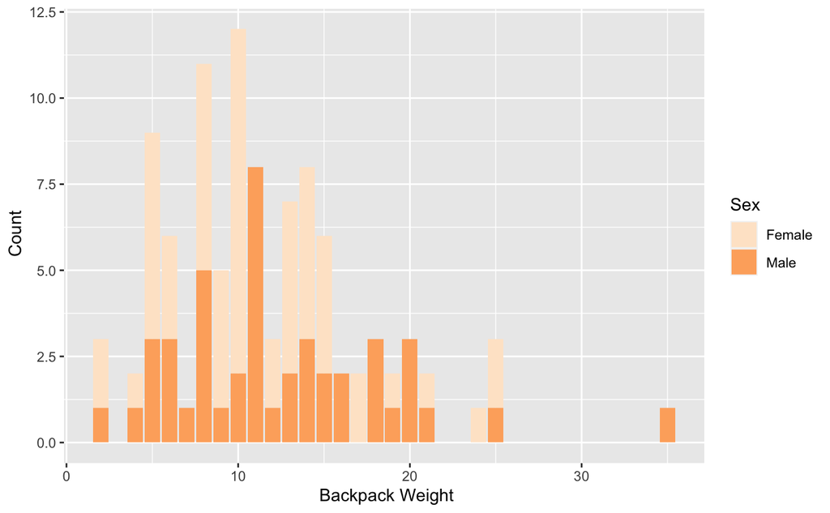

```r
ggplot(backpack) +
  geom_bar(aes(x = backpack_weight, fill = sex)) +
  scale_fill_brewer(palette = 7) +
  labs(
    x = " Backpack Weight",
    y = " Count",
    fill= "Sex"
  )
```

```r
NA
NA
```

This graph shows that more females carried 5-10 (lbs) of backpack weight than males,

SOLUTION

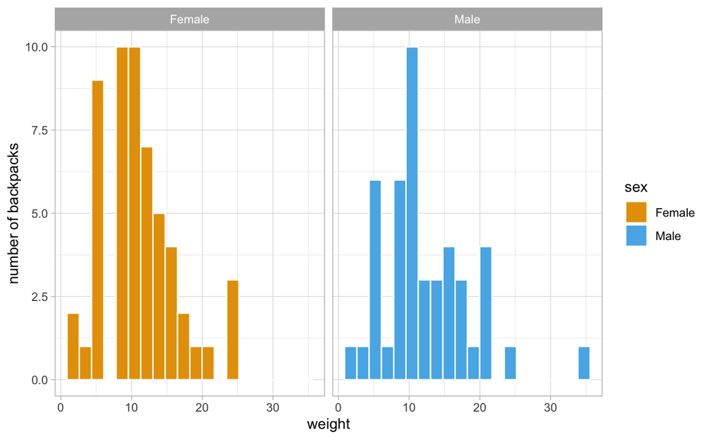

```r
# women or men carrying heavier backpacks?
ggplot(backpack) +
  aes(x = backpack_weight, fill = sex) +
  scale_fill_manual(values=c('#E69F00', '#56B4E9')) +
  geom_histogram(bins = 20, col = "white") +
  theme_light() +
  labs(y = "number of backpacks", x = "weight") +
  facet_wrap(~sex)
```

This tells us there are very similar distributions for backpack weights across males and female

Q4. What is the relationship between body weight and backpack weight?

```r
ggplot(backpack) +
  geom_jitter(aes(x = backpack_weight, y = body_weight), colour = "blue", height = 5, width = 10)
```

[output not shown]

SOLUTION

```r
# relationship between weight and backpack weight?
ggplot(backpack) +
  aes(x = body_weight, y = backpack_weight) +
  geom_point() +
  labs(x = "body weight", y = "backpack weight")
```

[output not shown]

Seems that there isn’t really a clear relationship. Perhaps those with higher body weights carry slightly heavier backpacks up to a point.

Q.5 Is this relationship different between men and women? Choose an appropriate plot and interpret your findings.

```r
ggplot(backpack) +
  geom_line(aes(x = body_weight, y = backpack_weight, colour = sex))
```

[output not shown]

The relationship between body weight and back_pack weight shows that in females in the smaller body weight -110-170 carried more bags beiween 10-20 or over. The males were between 150-200 in body weight

SOLUTION

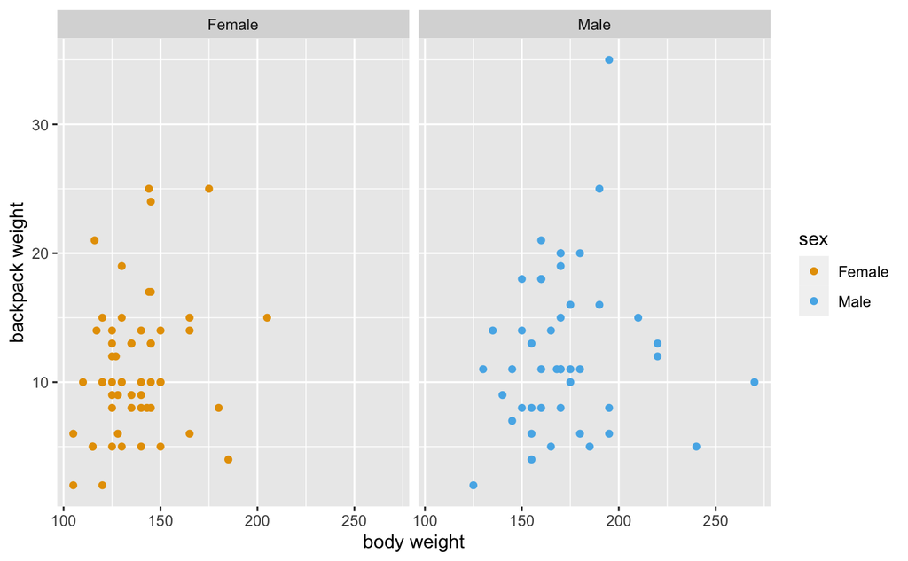

```r
# different for males vs females?
ggplot(backpack) +
  aes(x = body_weight, y = backpack_weight, color = sex) +
  geom_point() +
  facet_wrap(~sex) +
    scale_color_manual(values=c('#E69F00', '#56B4E9'))+
    labs(x = "body weight", y = "backpack weight")
```

Plot suggests that women might weigh less, but they’re not carrying less heavy backpacks…

Q6. What proportion of students report back pain?

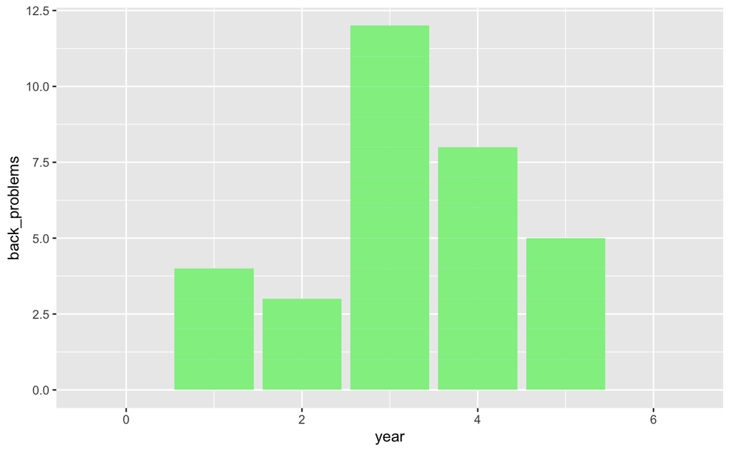

```r
ggplot(backpack) +
  geom_col(aes(x = year, y = back_problems), fill = "Light Green")
```

This graph shows that the proportion of year 3 students reported back pain, which means that younger and older students did not have as many problems

SOLUTION

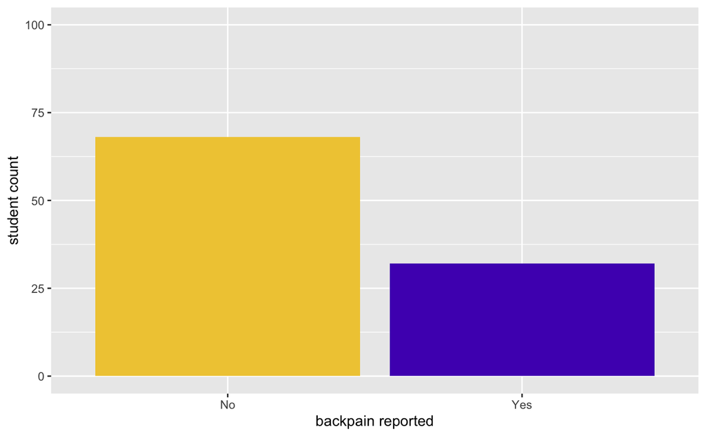

```r
# convert backpain to factor and create labelled column
backpack <- backpack %>%
  mutate(backpain_labelled = recode(back_problems,
                       "0" = "No",
                       "1" = "Yes"))

ggplot(backpack) +
  aes(x = backpain_labelled, fill = backpain_labelled) +
  geom_bar() +
ylim(0,100) +
  labs(x = "backpain reported", y = "student count") +
    scale_fill_manual(values=c('#f0ca41', '#5022bd'))+
theme(legend.position = "none")
```

Suggests ~ 30 students have backpain. That’s 1/3…

Q7 Is this proportion different between men and women?

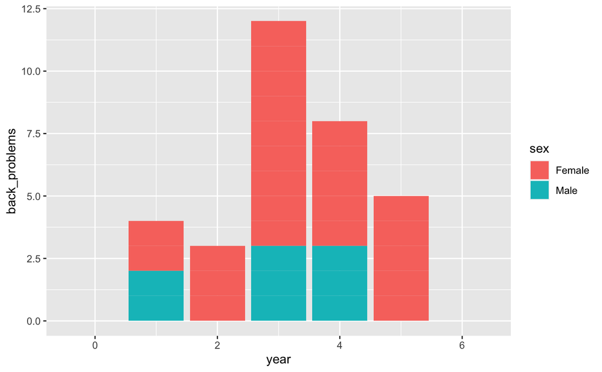

```r
ggplot(backpack) +
  geom_col(aes(x = year, y = back_problems, fill = sex))
```

SOLUTION

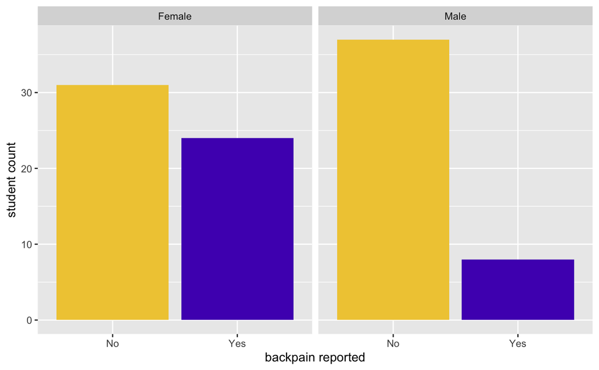

```r
# is it different for males and females?
ggplot(backpack) +
  aes(x = backpain_labelled, fill = backpain_labelled) +
  geom_bar() +
  labs(x = "backpain reported", y = "student count") +
  facet_wrap(~sex) +
      scale_fill_manual(values=c('#f0ca41', '#5022bd'))+
theme(legend.position = "none")
```

Interesting… more females report it than males. Perhaps something to do with them weighing less but carrying similarly heavy backpacks?

Q8. Now you’ve investigated your data separately, create plots to describe the relationship between backpack weight, body weight, gender and reported backpain. Try both backpack_weight and body_weight as well as the ratio.

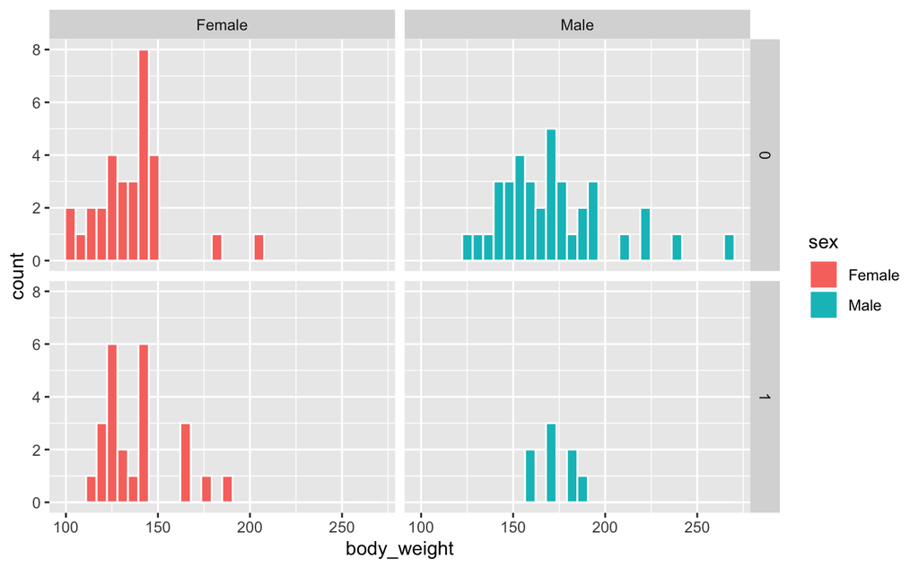

```r
ggplot(backpack) +
  geom_histogram(aes(x = body_weight, fill = sex), col = "white") +
  facet_grid(back_problems ~ sex)
```

This graph shows the females and males that did and didn’t have back problems, and their body weight

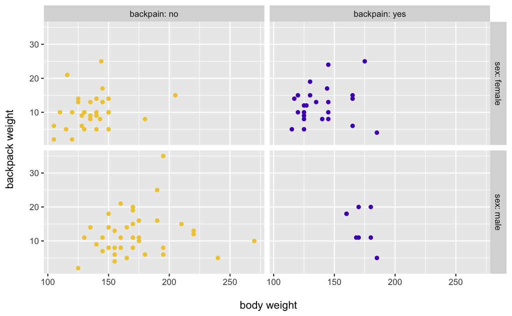

```r
# make the labels nice
pain_labels <- c("backpain: no", "backpain: yes")
names(pain_labels) <- c("No", "Yes")

sex_labels <- c("sex: female", "sex: male")
names(sex_labels) <- c("Female", "Male")


ggplot(backpack) +
  aes(x = body_weight, y = backpack_weight, color = backpain_labelled) +
  geom_point() +
  facet_grid(sex ~ backpain_labelled,
             labeller = labeller(backpain_labelled = pain_labels, sex = sex_labels)) +
  labs(x = "\n body weight", y = "backpack weight \n") +
      scale_color_manual(values=c('#f0ca41', '#5022bd'))+
theme(legend.position = "none")
```

Seems there is a relationship between backpack weight, body weight, gender and reported backpain….

Could be weird, let’s plot the ratio to confirm

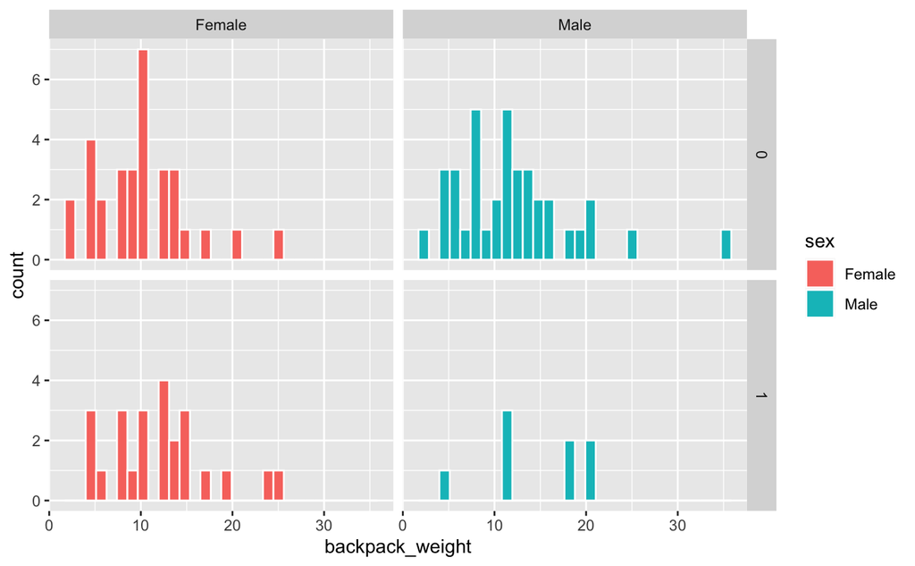

```r
ggplot(backpack) +
  geom_histogram(aes(x = backpack_weight, fill = sex), col = "white") +
  facet_grid(back_problems ~ sex)
```

```r
NA
NA
```

This graph shows the females and males that did and didn’t have back problems, and their backpack weight

SOLUTION

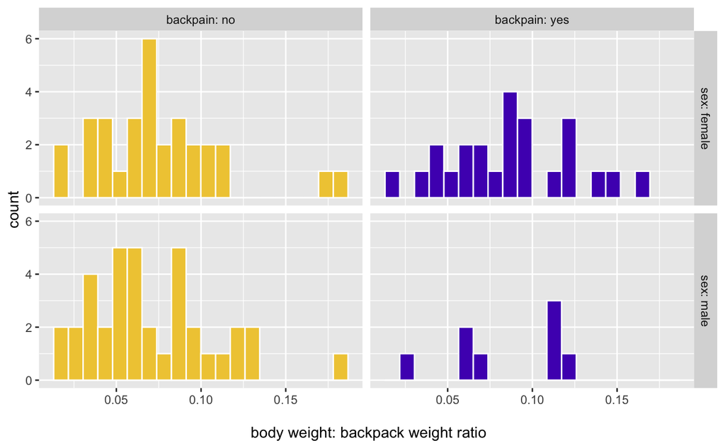

```r
ggplot(backpack) +
  geom_histogram(aes(x = ratio, fill = backpain_labelled), bins = 20, col = "white") +
  facet_grid(sex ~ backpain_labelled,
             labeller = labeller(backpain_labelled = pain_labels, sex = sex_labels)) +
  labs(x = "\n body weight: backpack weight ratio") +
      scale_fill_manual(values=c('#f0ca41', '#5022bd'))+
theme(legend.position = "none")
```

Everything still seems to be the same. Women seem to be reporting more backpack than men.

Sum up: the main area of focus seems to be on the differences in reported backpain across the different biological sexes. That’s maybe an area to focus on. Plus, collect more data so we can do the analysis across majors and years more thoroughly.

EXTENSION

Does reported backpain differ across the year groups? Ignore year 0 in your data.

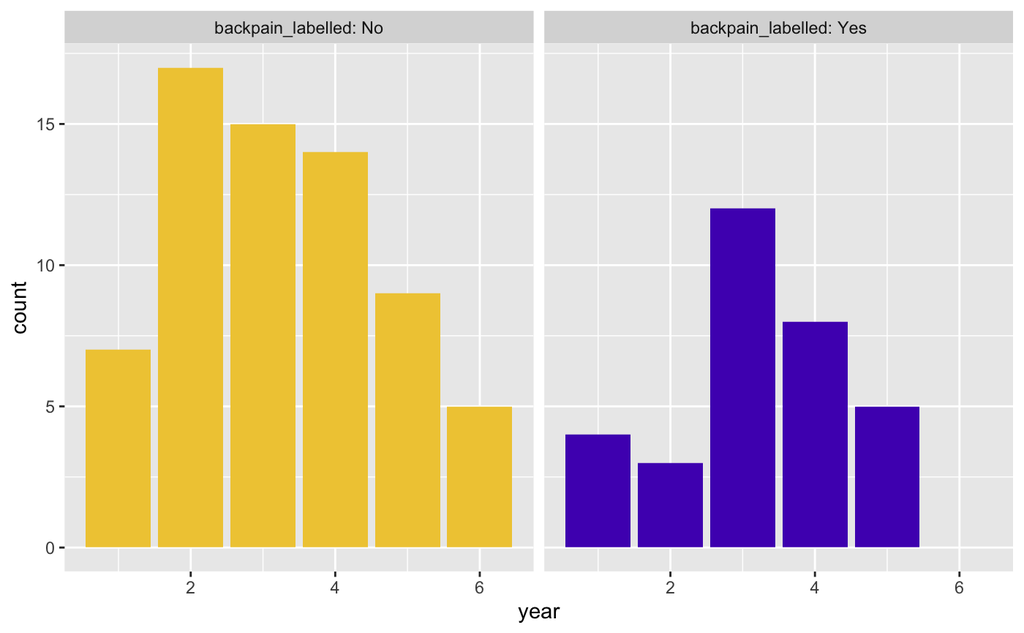

```r
subset_backpacks <- backpack %>%
  filter(year >0)

# look at the years
ggplot(subset_backpacks) +
  geom_bar(aes(x=year, fill = backpain_labelled)) +
  facet_wrap(~backpain_labelled, labeller = "label_both") +
      scale_fill_manual(values=c('#f0ca41', '#5022bd'))+
theme(legend.position = "none")
```

Could be something here… years 3 and 4 reported backpain are creeping together showing an increase in reported backpain from year 1 -> 3, then it goes back down. But you also have an increase in NO reported backpack as well. What this probably means instead is that we have more data for year 3 than we do for year 2. Proceed with caution before making any claims on this one…

Is there a difference between how heavy the bags those in different years carry?

SOLUTION

```r
# is there a difference between how heavy the bags those in different years carry?

ggplot(subset_backpacks)+
  geom_bar(aes(x=backpack_weight)) +
  facet_wrap(~year, ncol = 3) +
  xlab("backpack weights")
```

[output not shown]

Here it might be tempting to say years 3 and 4 have more people carrying heavy bags, but it actually seems more like it is the data that’s not great in the end ones and we need to collect more data before handing out health and well being leaflets to the middle years…